# Linear regression

## Exercise

- Data assumptions: show data distribution and discuss about Normality and Linearity
- Perform the linear regression analysis
- Model evaluation: discuss model result

## Data

```r
#load data
dataForAnalysis <- read.csv("https://raw.githubusercontent.com/couthcommander/sip_computing/main/labs/sot-covid.csv",header=TRUE,row.names=1)

dataForAnalysis$organ=factor(dataForAnalysis$organ)

head(dataForAnalysis)
```

```
##   organ immuno mopost age male  rbd1  rbd2  rbd3  ecd1  ecd2  ecd3   nc1   nc2
## 1     0      0      0  55    1 0.426 0.755 1.889 0.417 0.749 1.716 0.184 0.207
## 2     0      0      0  72    1 0.098 1.018 2.632 0.184 0.880 2.151 0.130 0.049
## 3     0      0      0  80    0 0.153 0.289 1.720 0.243 0.362 1.404 0.333 0.352
## 4     0      0      0  57    0 0.118 1.446 2.329 0.148 1.463 1.983 0.095 0.107
## 5     0      0      0  56    1 0.154 0.632 2.119 0.158 0.403 1.468 0.191 0.211
## 6     0      0      0  53    1 0.124 0.961 2.270 0.127 0.988 1.805 0.147 0.085
##     nc3 bead_rbd1 bead_rbd2 bead_rbd3
## 1 0.248        43      1145     41469
## 2 0.146        24     20682    205766
## 3 0.256        16       346     14667
## 4 0.148        13      2120     37985
## 5 0.205        13       735     29884
## 6 0.125        12      2153     26098
```

**Question**: Is ELISA response to nucleocapsid protein at three weeks (nc2) associated with baseline (nc1) and other factors including organ and age?

### Exercise 1: Data visualization

Use some pictures (histogram, scatter plot, or box plot,…) to show the distribution of all factors (nc2, nc1, age, and organ); Think about: (1) Assess the data assumptions (Normality and Linearity) for linear regression; (2) Based on (1), do you think we need to perform a log transformation on nc1 and nc2? (3) What is the relationships between nc1, nc2, age, and organ;

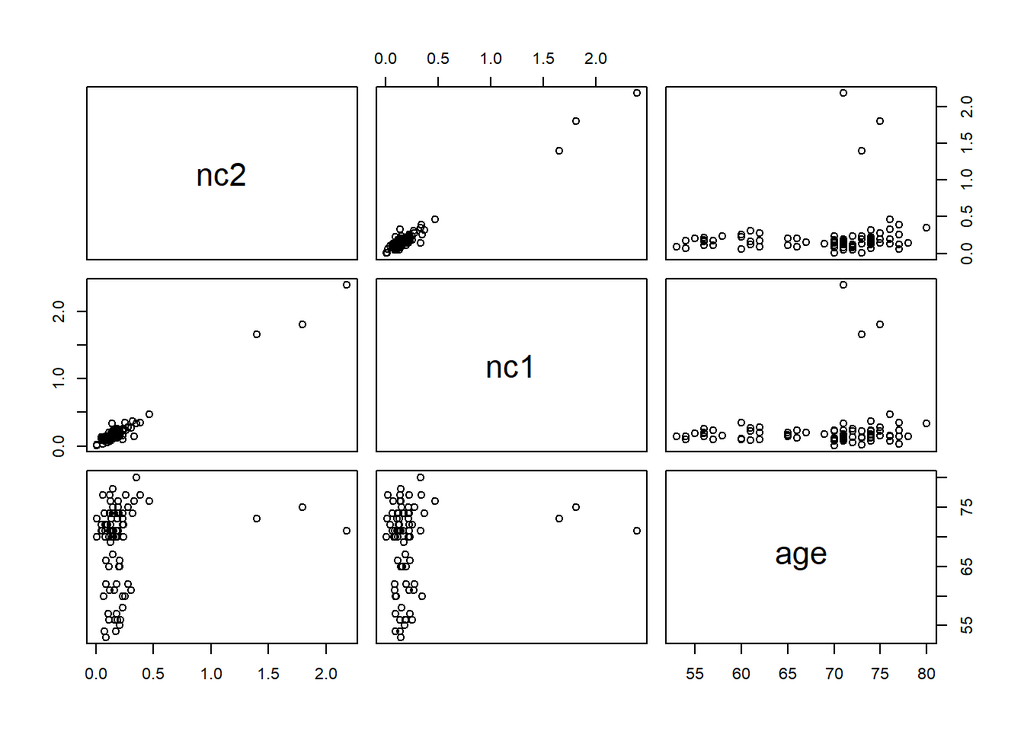

```r
plot(dataForAnalysis[,c("nc2","nc1","age")])
```

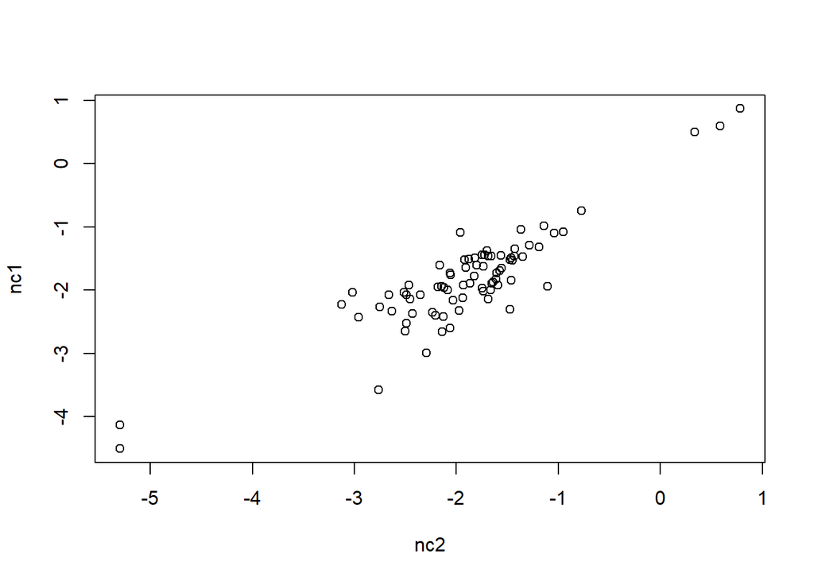

```r
plot(log(dataForAnalysis[,c("nc2","nc1")]))
```

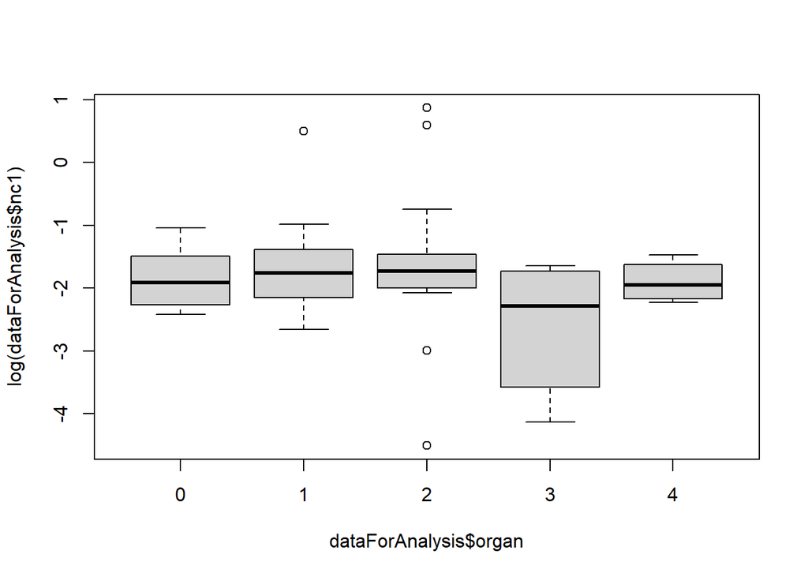

```r
boxplot(log(dataForAnalysis$nc1)~dataForAnalysis$organ)
```

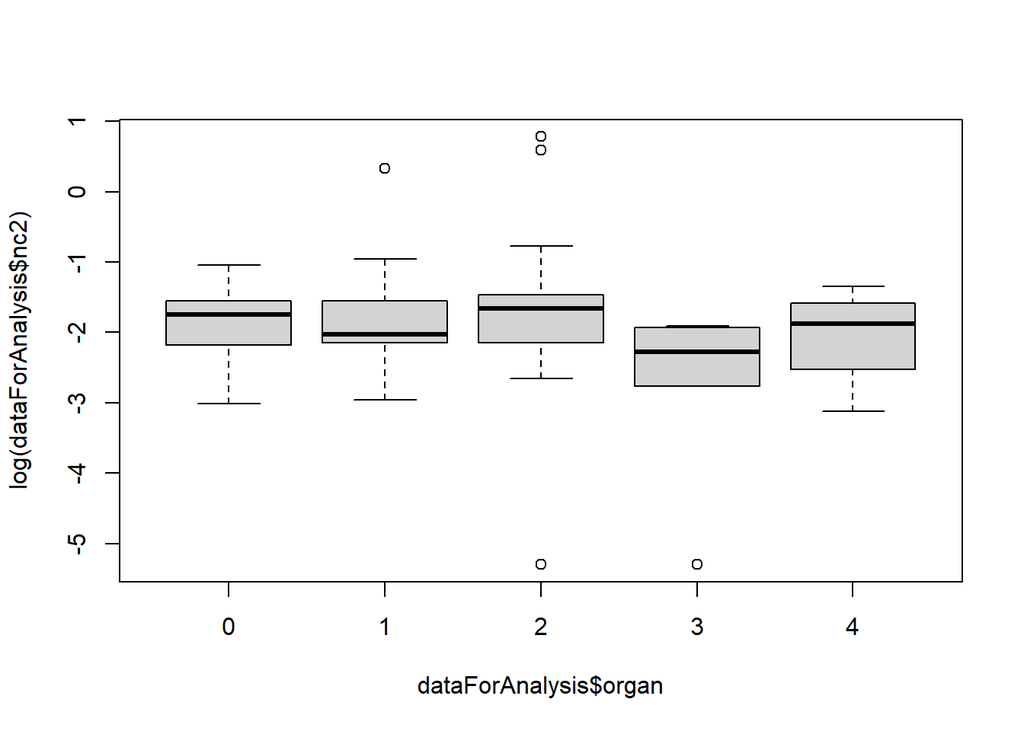

```r
boxplot(log(dataForAnalysis$nc2)~dataForAnalysis$organ)
```

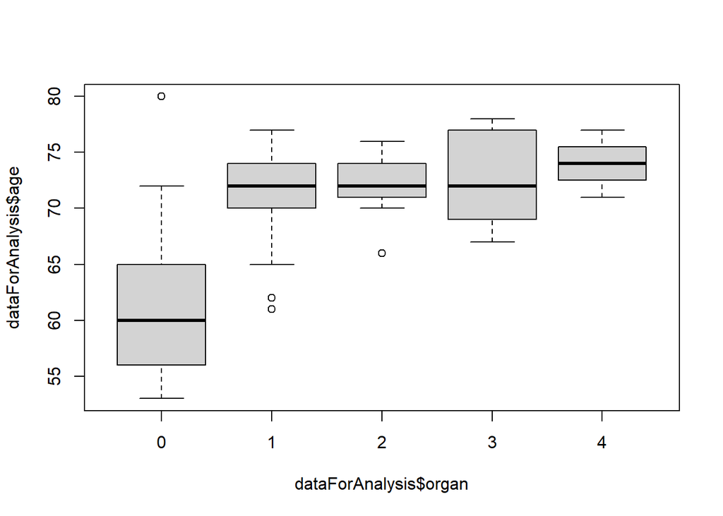

```r
boxplot(dataForAnalysis$age~dataForAnalysis$organ)
```

### Exercise 2: Perform simple linear regression analysis

Using nc2 as Y, nc1 as X

```r
modelResult <- lm(log(nc2) ~ log(nc1), data = dataForAnalysis)
```

### Exercise 3: Model interpretation

1. Is nc1 significantly associated with nc2? What is the coefficient of nc1? What does it mean?
2. Use a scatter plot to show the nc1 in X axis, and nc2 in Y axis. Add the fitted regression line.
3. Make residual plot to assess the Homoscedasticity assumption.

```r
summary(modelResult)
```

```
##
## Call:
## lm(formula = log(nc2) ~ log(nc1), data = dataForAnalysis)
##
## Residuals:
##     Min      1Q  Median      3Q     Max
## -1.1239 -0.2391  0.0320  0.1978  0.8998
##
## Coefficients:
##             Estimate Std. Error t value Pr(>|t|)
## (Intercept) -0.08518    0.11156  -0.764    0.447
## log(nc1)     0.98889    0.05633  17.554   <2e-16 ***
## ---
## Signif. codes:  0 '***' 0.001 '**' 0.01 '*' 0.05 '.' 0.1 ' ' 1
##
## Residual standard error: 0.3934 on 78 degrees of freedom
## Multiple R-squared:  0.798,  Adjusted R-squared:  0.7954
## F-statistic: 308.1 on 1 and 78 DF,  p-value: < 2.2e-16
```

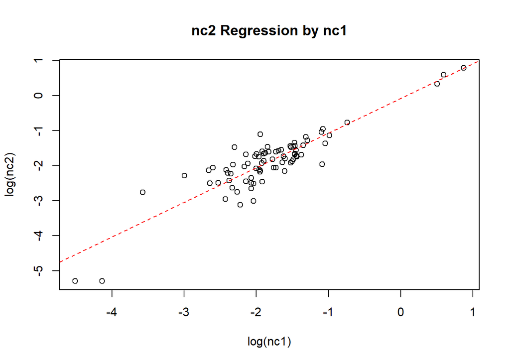

```r
plot(log(nc2) ~ log(nc1), data =dataForAnalysis,main = "nc2 Regression by nc1")
abline(modelResult,lty=2,col="red")
```

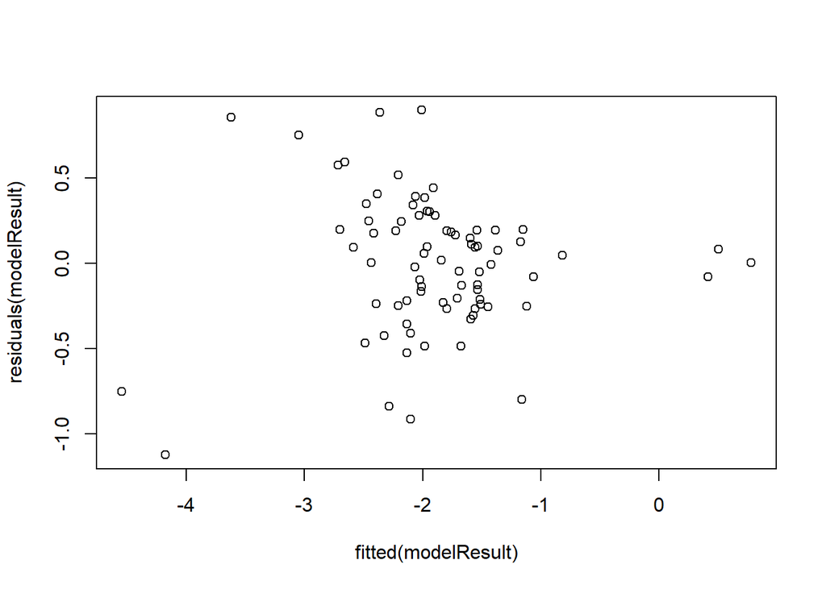

```r
plot(fitted(modelResult),residuals(modelResult))
```

### Exercise 4: Perform multiple linear regression analysis

Using nc2 as Y; nc1, age, and organ as X

```r
modelResult <- lm(log(nc2) ~ log(nc1)+age+organ, data = dataForAnalysis)
```

### Exercise 5: Use the model to predict the nc2 value for a new subject.

```r
newData <- data.frame(age = c(Subject1=3,Subject2=4),nc1=c(0.126,0.153),organ=factor(c(1,2)))
predict(modelResult,newdata = newData)
```

```
##  Subject1  Subject2
## -3.194966 -2.974082
```